# LAYOFFS EM TECNOLOGIA NO BRASIL

## Uma breve conjectura sobre o mercado pós-pandemia

###### Por: Everton Amarantes de Faria

Durante os anos de 2020 e 2021, o mundo viu um boom na contratação de profissionais de tecnologia. No entanto, o cenário macroeconômico mudou a partir de 2022, e a palavra Layoff se tornou rotina. Através deste projeto de People Analytics, o objetivo é isolar e entender os padrões de cortes no cenário corporativo brasileiro utilizando dados reais.

```python
import pandas as pd
import matplotlib.pyplot as plt
import seaborn as sns

caminho = r'C:\Users\amara\Desktop\Projetos\Data\Layoff TECH\Dados Tratados\Cleaned_tech_layoffs.csv'
df = pd.read_csv(caminho)

df_brasil = df[df['Country'] == 'Brazil'].copy()

display(df_brasil.head())
```

|  | Date_layoffs | Company | City | Country | Laid_Off | Percentage | Company_Size_before_Layoffs | Company_Size_after_layoffs | Money_Raised_in__mil | Industry | Year |
| --- | --- | --- | --- | --- | --- | --- | --- | --- | --- | --- | --- |
| 0 | 08/08/22 | Loggi | Sao Paulo | Brazil | 5000 | 150 | 33330 | 28330 | 5070 | Logistics | 2022 |
| 1 | 03/04/20 | Gympass | Sao Paulo | Brazil | 4670 | 330 | 14150 | 9480 | 3000 | Fitness | 2020 |
| 2 | 05/07/22 | Loft | Sao Paulo | Brazil | 3840 | 120 | 32000 | 28160 | 7880 | Real Estate | 2022 |
| 3 | 01/03/23 | iFood | Sao Paulo | Brazil | 3550 | 60 | 59170 | 55620 | 21000 | Food | 2023 |
| 4 | 03/03/23 | Loft | Sao Paulo | Brazil | 3400 | 150 | 22670 | 19270 | 7880 | Real Estate | 2023 |

### 1. Quais os setores da tecnologia que mais cortaram postos de trabalho?

Para compreender a dimensão do impacto, é fundamental isolar os dados por indústria. Abaixo, o Top 10 dos setores com o maior volume de profissionais afetados no Brasil.

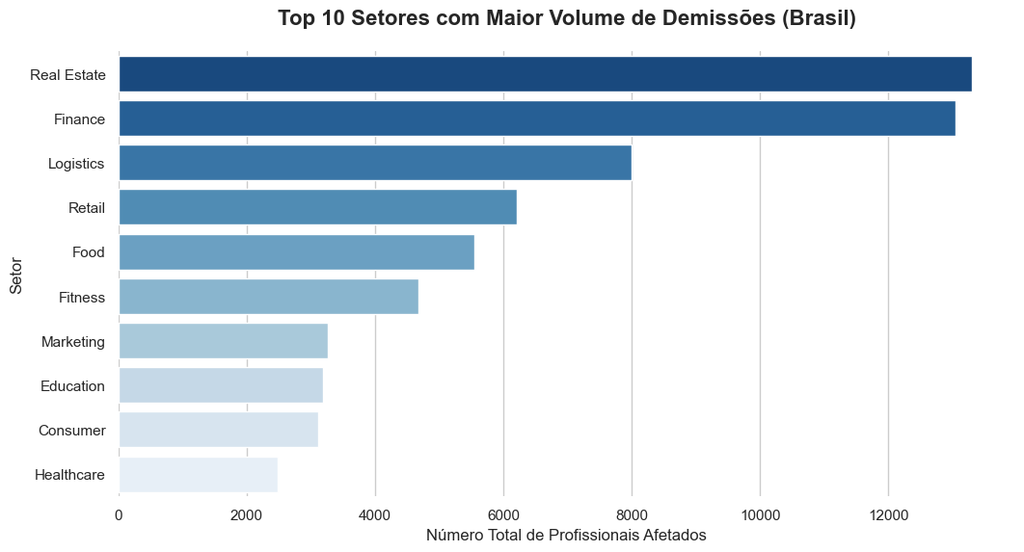

```python
setores_afetados = df_brasil.groupby('Industry')['Laid_Off'].sum().sort_values(ascending=False).head(10)

plt.figure(figsize=(12, 6))
sns.set_theme(style="whitegrid")

sns.barplot(x=setores_afetados.values, y=setores_afetados.index, hue=setores_afetados.index, palette="Blues_r", legend=False)

plt.title('Top 10 Setores com Maior Volume de Demissões (Brasil)', fontsize=16, fontweight='bold', pad=20)
plt.xlabel('Número Total de Profissionais Afetados', fontsize=12)
plt.ylabel('Setor', fontsize=12)
sns.despine(left=True, bottom=True)

plt.show()
```

### 2. Quais empresas lideraram as reduções de quadro no Brasil?

Sabendo que o setor Imobiliário (Real Estate) e outros setores de capital intensivo foram os mais afetados, o próximo passo lógico é identificar quais organizações específicas realizaram os maiores cortes. Isso nos ajuda a entender se o volume de demissões foi pulverizado entre muitas startups ou concentrado em poucos "unicórnios" (empresas avaliadas em mais de 1 bilhão de dólares).

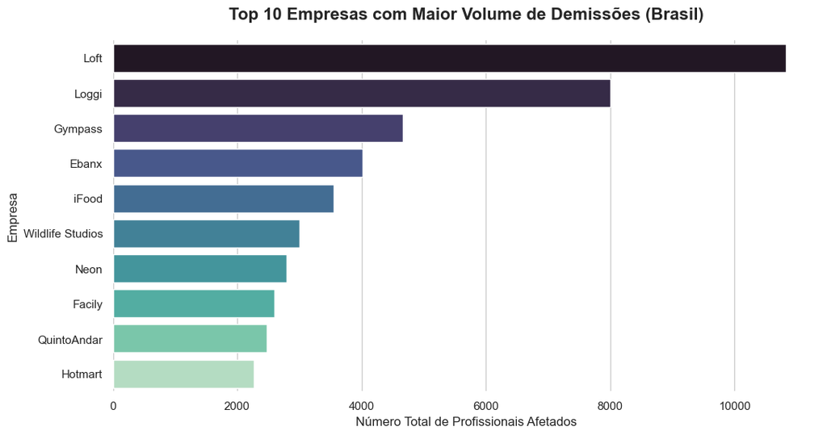

```python
#Agrupando os dados agora por Empresa (Company)
empresas_afetadas = df_brasil.groupby('Company')['Laid_Off'].sum().sort_values(ascending=False).head(10)

#Visual
plt.figure(figsize=(12, 6))
sns.set_theme(style="whitegrid")

# Gráfico de barras
sns.barplot(x=empresas_afetadas.values, y=empresas_afetadas.index, hue=empresas_afetadas.index, palette="mako", legend=False)

#Títulos e Bordas
plt.title('Top 10 Empresas com Maior Volume de Demissões (Brasil)', fontsize=16, fontweight='bold', pad=20)
plt.xlabel('Número Total de Profissionais Afetados', fontsize=12)
plt.ylabel('Empresa', fontsize=12)
sns.despine(left=True, bottom=True)

plt.show()
```

### 3. Qual foi o pior ano para os profissionais de tecnologia no Brasil?

Depois de identificar os setores e as empresas mais afetadas, é fundamental entender a distribuição temporal desses cortes. O "boom" de contratações ocorreu durante o auge da pandemia (2020-2021). Será que as demissões acompanharam o fim das restrições sanitárias ou foram motivadas pela alta global dos juros a partir de 2022?

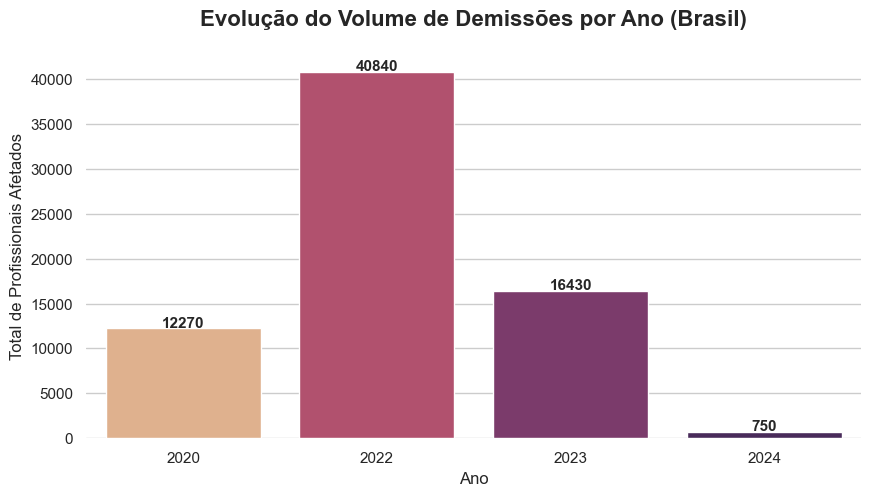

```python
#Agrupando os dados por Ano
demissoes_por_ano = df_brasil.groupby('Year')['Laid_Off'].sum().sort_index()

#Visual
plt.figure(figsize=(10, 5))
sns.set_theme(style="whitegrid")

#Criando o gráfico de barras verticais
sns.barplot(x=demissoes_por_ano.index, y=demissoes_por_ano.values, hue=demissoes_por_ano.index, palette="flare", legend=False)

#Títulos e formatação
plt.title('Evolução do Volume de Demissões por Ano (Brasil)', fontsize=16, fontweight='bold', pad=20)
plt.xlabel('Ano', fontsize=12)
plt.ylabel('Total de Profissionais Afetados', fontsize=12)

# Adicionando os números exatos em cima de cada barra para facilitar a leitura do recrutador
for index, value in enumerate(demissoes_por_ano.values):
    plt.text(index, value + 100, f'{int(value)}', ha='center', fontsize=11, fontweight='bold')

sns.despine(left=True, bottom=True)

# Exibindo o gráfico
plt.show()
```

### 4. Onde esses cortes estão geograficamente concentrados?

A tecnologia tem o poder de descentralizar o trabalho, especialmente com o modelo remoto adotado intensamente na pandemia. No entanto, analisando a localização sede das empresas que realizaram os layoffs, podemos verificar se os polos tecnológicos do Brasil ainda se concentram nos grandes eixos financeiros.

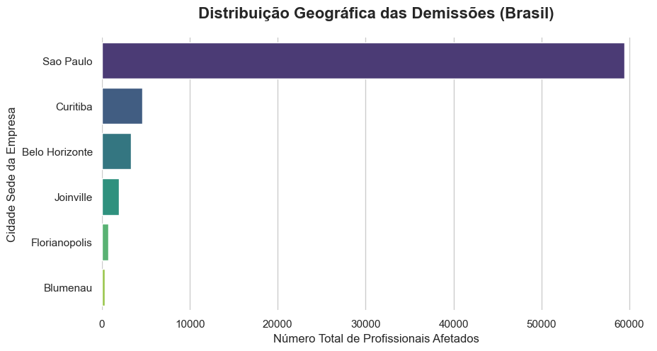

```python
#Agrupando os dados por Cidade
cidades_afetadas = df_brasil.groupby('City')['Laid_Off'].sum().sort_values(ascending=False)

#Visual
plt.figure(figsize=(10, 5))
sns.set_theme(style="whitegrid")

#Gráfico de barras horizontais
sns.barplot(x=cidades_afetadas.values, y=cidades_afetadas.index, hue=cidades_afetadas.index, palette="viridis", legend=False)

#Títulos
plt.title('Distribuição Geográfica das Demissões (Brasil)', fontsize=16, fontweight='bold', pad=20)
plt.xlabel('Número Total de Profissionais Afetados', fontsize=12)
plt.ylabel('Cidade Sede da Empresa', fontsize=12)
sns.despine(left=True, bottom=True)

plt.show()
```

### 5. A Ilusão das Manchetes: Qual foi o impacto proporcional nas empresas?

Na imprensa, os números absolutos geram mais cliques. A Loggi demitiu milhares de pessoas e foi capa de jornal. No entanto, o verdadeiro termômetro de sobrevivência de uma organização não é o número total de cortes, mas sim o percentual (a proporção) do quadro que foi reduzido.

Demitir 1.000 pessoas numa empresa de 20.000 significa um ajuste de 5%. Cortar 40 pessoas numa empresa de 40 significa o encerramento da operação. Abaixo, mudo a lente da análise para descobrir quais empresas sofreram o corte mais agressivo em sua estrutura fundamental.

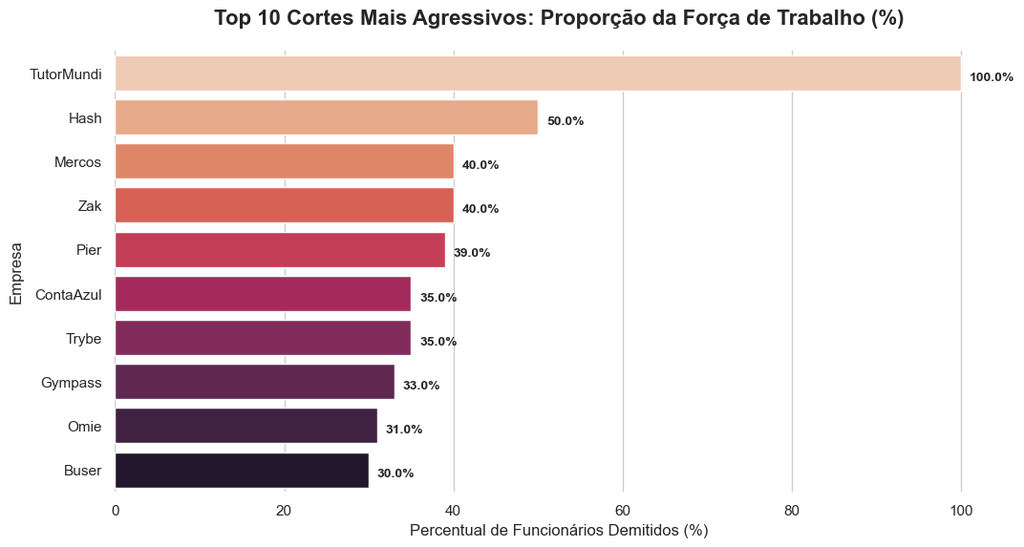

```python
#Tratamento de Dados: Ajustando a coluna de porcentagem (0-100%)
df_brasil['Porcentagem_Real'] = df_brasil['Percentage'] / 10

#Agrupando as empresas pelos maiores corte
cortes_percentuais = df_brasil.groupby('Company')['Porcentagem_Real'].max().sort_values(ascending=False).head(10)

#Visual
plt.figure(figsize=(12, 6))
sns.set_theme(style="whitegrid")

#Criando o gráfico de barras (Paleta 'rocket_r' para indicar criticidade)
sns.barplot(x=cortes_percentuais.values, y=cortes_percentuais.index, hue=cortes_percentuais.index, palette="rocket_r", legend=False)

plt.title('Top 10 Cortes Mais Agressivos: Proporção da Força de Trabalho (%)', fontsize=16, fontweight='bold', pad=20)
plt.xlabel('Percentual de Funcionários Demitidos (%)', fontsize=12)
plt.ylabel('Empresa', fontsize=12)

# Adicionando o %
for index, value in enumerate(cortes_percentuais.values):
    plt.text(value + 1, index + 0.1, f'{value:.1f}%', va='center', fontsize=10, fontweight='bold')

sns.despine(left=True, bottom=True)
plt.show()
```

### 6. O Paradoxo do Capital: Mais dinheiro levantado significa mais segurança?

Existe um mito no mercado de que trabalhar em empresas "Unicórnios", que levantaram rios de dinheiro de investidores, traz segurança. A hipótese que trago aqui é: será que o excesso de capital não financiou, na verdade, um crescimento desordenado e ineficiente?

Através de um Gráfico de Dispersão, cruzei o Volume de Dinheiro Captado pela empresa (em Milhões) contra o Volume de Demissões geradas por ela.

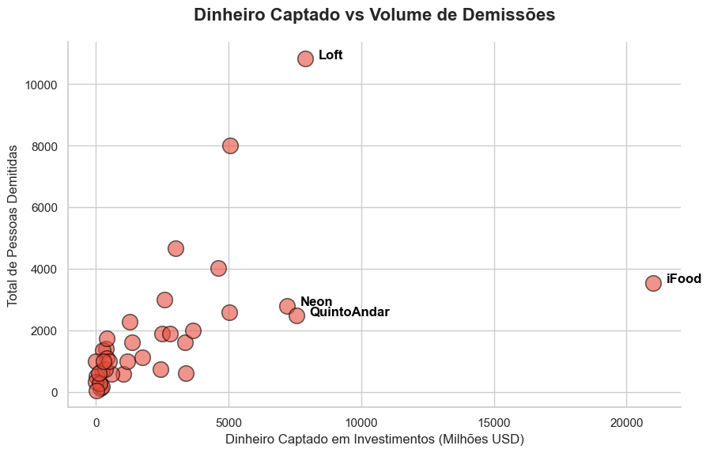

```python
#Cruzando Dinheiro Captado (Máximo) vs Demissões (Soma de todas as rodadas)
investimento_vs_cortes = df_brasil.groupby('Company').agg({'Money_Raised_in__mil':'max', 'Laid_Off':'sum'}).dropna()

#Visual
plt.figure(figsize=(10, 6))
sns.set_theme(style="whitegrid")

#Criando o gráfico de dispersão (Scatterplot)
sns.scatterplot(data=investimento_vs_cortes,
                x='Money_Raised_in__mil',
                y='Laid_Off',
                s=200,          # Tamanho das bolhas
                color='#e74c3c', # Vermelho corporativo
                alpha=0.6,      # Transparência
                edgecolor='black')

#Rótulos apenas nos maiores "ofensores"
ofensores = investimento_vs_cortes.sort_values(by='Money_Raised_in__mil', ascending=False).head(4)
for linha in range(0, ofensores.shape[0]):
    plt.text(ofensores['Money_Raised_in__mil'].iloc[linha] + 500,
             ofensores['Laid_Off'].iloc[linha],
             ofensores.index[linha],
             horizontalalignment='left', size='medium', color='black', weight='semibold')

#Personalizações
plt.title('Dinheiro Captado vs Volume de Demissões', fontsize=16, fontweight='bold', pad=20)
plt.xlabel('Dinheiro Captado em Investimentos (Milhões USD)', fontsize=12)
plt.ylabel('Total de Pessoas Demitidas', fontsize=12)
sns.despine()

plt.show()
```

### Reflexão Final: O Futuro do People Analytics

Os dados nos contam uma história clara: a era do *"Crescimento a Qualquer Custo" (Growth at all costs)* acabou. O capital em excesso, quando não acompanhado de governança e de eficiência operacional, mascarou ineficiências gravíssimas nas contratações do mercado de tecnologia. A conta da hiper-escala inconsequente chegou a partir de 2022.

O *Layoff* não é apenas o reflexo de uma economia externa (macro), mas o resultado inevitável de um planejamento interno reativo.

O papel do **Profissional de Dados** moderno não é apenas construir os gráficos para contabilizar demissões que já aconteceram. A verdadeira ciência de dados em People Analytics está em agir antes: é modelar a eficiência estrutural, prever o inchaço de equipes, ajudar líderes a contratarem com propósito real e, acima de tudo, construir organizações financeiramente saudáveis que protegem os seus maiores ativos: **as pessoas.**